# Final Group Project - Modeling Approach and Evaluation

### Luke Therieau - Jason Michaud - Nathan Angell - Robert Mitchell

## Libaries Utilized:

```python
import pandas as pd
import warnings
from sklearn.model_selection import train_test_split
%pylab inline
warnings.filterwarnings('ignore')
```

## Functions Used:

### OHE()

For transformation of the categorical features of dataframe into ones for use in ML

```python
def OHE(df):

    #Load Label Encoder
    from sklearn.preprocessing import LabelEncoder
    labelEncoder = LabelEncoder()

    #For all Categorical Features, Using OHE, will be transformed for ML to handle.
    for column in list(df.dtypes[(df.dtypes == object)|(df.dtypes == bool)].index):
        df[column] = labelEncoder.fit_transform(df[column].values)

    #Return transformed dataframe
    return df
```

### ConfusionMatrix()

For visualization of the Confusion Matrix of a model

```python
def ConfusionMatrix(y_test, treePred):

    # Create Confusion Matrix via arrays
    from sklearn.metrics import confusion_matrix
    cf_matrix = confusion_matrix(y_test, treePred)

    #Turn those arrays into a single dimension than can then be unpacked into varibles
    tn, fp, fn, tp = cf_matrix.ravel()

    #Graph Confusion Matrix using those 4 varibles which will represent the 4 areas of this graph.
    figure(figsize(10,7))

    from matplotlib import colors

    #Colors of plot (Red = False, Green = True)
                                        #Red - Green - Green - Red
    cmap = colors.ListedColormap(['#E64905','#0A925B','#0A925B','#E64905'])

    #Boundaries of Plot
    bounds=[-0.5, 0.5, 1.5, 2.5, 3.5]
    norm = colors.BoundaryNorm(bounds, cmap.N)

    #Use heatmap as template for Confusion Matrix
    heatmap = pcolor(array([[0,1],[2,3]]), cmap=cmap, norm=norm)

    #Label the 4 areas of the graph with their respective values and names
    text(x=0.35,y=1.35,s=f"TP\n{tp}",size=30) #True Positive
    text(x=1.35,y=1.35,s=f"FP\n{fp}",size=30) #False Positive
    text(x=0.35,y=0.35,s=f"FN\n{fn}",size=30) #False Negative
    text(x=1.35,y=0.35,s=f"TN\n{tn}",size=30) #True Negative

    #Remove the outlines of the plot for each side
    for side in ['bottom','top','right','left']:
        gca().spines[side].set_visible(False)

    #Remove x and y axis ticks
    xticks([])
    yticks([])

    #True Class Label usine title
    title("True Class\nPositive                 Negative",size=30)

    #Predicted Class Label using ylabel
    ylabel("Predicted Class\nNegative     Positive",size=30)

    #Show Plot
    show()
```

### ConfusionStats()

Will be used to gather information on the following about a specific model:

```
for each dataset:

    for each target value:
```

- Dataset
- Features
- Target
- AUC
- Accuracy
- Precision
- Recall
- F1-Score
- Frequency
- Deltas of metrics listed for comparision between training and test datasets

```python
def ConfusionStats(model,X_train, X_test, y_train, y_test):

    #libraries Used:
    from sklearn.metrics import confusion_matrix
    from sklearn.metrics import roc_auc_score

    #Data Container for Final Results
    ConfusionDF = []

    #For Each Dataset (Train or Test), metrics will be gathered for comparison
    for dataset, y, X in zip(['Train','Test'],[y_train,y_test],[X_train,X_test]):

        #Generate Confusion metric
        cf_matrix = confusion_matrix(y, model.predict(X))

        #Unpaxck results into 4 varibles
        tn, fp, fn, tp = cf_matrix.ravel()

        #Calculate accuracy and auc which are the same for both 0 and 1 target varible:
        accuracy = (tp+tn)/(tp+tn+fp+fn)
        auc = roc_auc_score(y, model.decision_function(X))

        #Recird features used:
        features = list(X.columns)

        #For each target varible (0 or 1), metrics will be gathered for comparison
        for target, trueTarget, falseTarget, flaseOtherTarget in zip([0,1],[tn,tp],[fn,fp],[fp,fn]):

            #Calculate precision or positive predictive value
            precision = trueTarget/(trueTarget+falseTarget)

            #Calculate recal or Sensitivity or True Positive rate
            recall = trueTarget/(trueTarget+flaseOtherTarget)

            #Harmonic mean of recal and precision
            f1 = 2*((precision*recall)/(precision+recall))

            #Append all results gathered so far into the final data container
            ConfusionDF.append([dataset,features,target,auc,accuracy,precision,recall,f1,y.value_counts()[target]])

    #Once the loop is finished, convert final data container into a dataframe
    ConfusionDF = pd.DataFrame(ConfusionDF,columns=['Dataset',
                                                    'Features',
                                                    'Target',
                                                    'AUC',
                                                    'Accuracy',
                                                    'Precision',
                                                    'Recall',
                                                    'F1-Score',
                                                    'Frequency']).round(4)

    #Focus data analysis on specific metrics of 'AUC','Accuracy','Precision','Recall','F1-Score' based on dataset
    #and specific target value
    metrics = ConfusionDF.drop(['Features','Frequency'],axis=1).set_index(['Dataset','Target'])

    #Final Data contianer for Metric Deltas (Difference between training and test datasets)
    df = []
    df.append([nan,nan,nan,nan]) #Training Dataset Delta - Not a priority
    df.append([nan,nan,nan,nan]) #Training Dataset Delta - Not a priority

    #For specific target (0 - 1), Difference between training and test datasets
    for target in [0,1]:
        df.append((metrics.loc[('Train',target)]-metrics.loc[('Test',target)]).values.tolist())

    #Add new metric deltas to the final dataframe
    ConfusionDF = pd.concat([ConfusionDF,pd.DataFrame(df,columns=[f'{col}_Delta'
                                                                  for col in metrics.columns])],axis=1)
    #return final dataframe for use in evalulation of model
    return ConfusionDF
```

## GBT()

```python
def GBT(data,min_samples_split,min_samples_leaf,n_estimators,learning_rate,max_depth):
    from sklearn.ensemble import GradientBoostingClassifier
    start = time.time()

    X_train, X_test, y_train, y_test = data

    model = GradientBoostingClassifier(min_samples_split = min_samples_split,
                                       min_samples_leaf = min_samples_leaf,
                                       n_estimators=n_estimators,
                                       learning_rate=learning_rate,
                                       max_depth=max_depth,
                                       max_features = 'sqrt',
                                       random_state=0).fit(X_train, y_train)

    print(f"{time.time() - start} seconds")

    columns = ['Model','Features','Dataset', 'Target', 'AUC', 'Accuracy', 'Precision', 'Recall', 'F1-Score',
               'Frequency', 'AUC_Delta','Accuracy_Delta', 'Precision_Delta', 'Recall_Delta','F1-Score_Delta']

    return [model] + ConfusionStats(model,X_train, X_test, y_train, y_test).loc[3].tolist(),columns
```

## calcuate_roc_curve()

```python
def calcuate_roc_curve(model,X_test):
    from sklearn.metrics import roc_curve
    fpr, tpr, thresholds = roc_curve(y_test, model.decision_function(X_test))
    return (model,fpr, tpr, thresholds)
```

## Graph_AUC()

```python
def Graph_AUC(models_list,X_test):
    from sklearn.metrics import roc_auc_score

    figure(figsize(10,6))

    #For every model for comparison
    for model,fpr, tpr, thresholds in models_list:

        #Plot Model Curve
        plot(fpr, tpr, label=f"{str(model).split('(')[0]} - AUC: {round(roc_auc_score(y_test, model.decision_function(X_test)),2)}")
        fill_between(fpr,tpr,alpha=0.2)

        #Find threshold closest to zero
        close_zero = np.argmin(np.abs(thresholds))
        plot(fpr[close_zero], tpr[close_zero], 'o', markersize=10, fillstyle="full", c='black', mew=2)

        #Threshold Value
        text(fpr[close_zero]+0.020, tpr[close_zero]-0.030,f'{round(tpr[close_zero],2)}\n{round(fpr[close_zero],2)}')

    #Used only for legend()
    plot(0, 0, 'o', markersize=1,label="threshold zeros", fillstyle="full", c='black', mew=2)

    #Labels
    xlabel("False Positive Rate",size=15)
    ylabel("True Positive Rate (recall)",size=15)
    title('ROC Curve',size=20)

    #Baseline
    plot([0, 1], [0, 1], color='red', linestyle='--',label='Baseline - AUC: 0.50')

    #Remove plot boundaries
    for side in ["right","top","bottom","left"]:
            gca().spines[side].set_visible(False)

    #Remove ticks
    xticks([])
    yticks([])

    #New Boundaries
    plot([0, 1], [0, 0],'-',color='red')   #Good Corner
    plot([1, 1], [0, 1],'-',color='red')   #Good Corner
    plot([0, 1], [1, 1],'-',color='green') #Bad Corner
    plot([0, 0], [0, 1],'-',color='green') #Bad Corner

    #New Range Labels
    text(-0.025,-0.05,'0',size=20)
    text(1.025,-0.05,'1',size=20)
    text(-0.025,1.05,'1',size=20)

    #Legend
    legend(bbox_to_anchor=(1, 0.35),fontsize=20)

    show()
```

## Graph_Model_Metrics()

```python
def Graph_Model_Metrics(results):
    figure(figsize(11,7))

    #Columns for results
    metrics = results.columns[4:-6] #Metrics Columns
    deltas = results.columns[-5:]   #Delta Columns

    #Calculate Training Results
    results_train = pd.DataFrame(results[metrics].values + results[deltas].values,columns = metrics)

    # Graph Training and Testing results for each Metric
    for metric in metrics:

        #Change Opacity based on condition to allow visiblility of both train and test
        if results_train[metric].values[0] > results[metric].values[0]:
            alpha = 1
        else:
            alpha = 0.8

        bar(metric,1,color='black')                           #Maximum Value
        bar(metric,results_train[metric],color='red')         #Training Metric
        bar(metric,results[metric],color='green',alpha=alpha) #Testing Metric

    #Remove plot boundaries
    for side in ["right","top","bottom","left"]:
        gca().spines[side].set_visible(False)

    #Labels & Ticks
    yticks([])
    xticks(size=18)
    title("Key Model Metrics",size=25)

    #Testing Data Labels
    for i, v in enumerate(results[metrics].values[0]):
        text(i, v-0.05, f'{round(v,4)}', color='black', fontsize=15, ha='center', va='center')

    #Training Data Labels
    for i, v in enumerate(results_train[metrics].values[0]):
        text(i, v+0.05, f'{round(v,4)}', color='red', fontsize=15, ha='center', va='center')

    text(-0.8,1,'1.0',size=15)

    #Legend
    legend(['Maximum','Train','Test'],fontsize=20,loc=(1,0))

    #Plot Results
    show()
```

## importanceDf()

```python
def importanceDf(features,model):
    return pd.DataFrame([[C,I] for C,I in zip(features.columns,model.feature_importances_)],columns = ['Feature','Importance']).sort_values('Importance',ascending=False)
```

```python
def importanceDf(features,model):
    return pd.DataFrame([[C,I] for C,I in zip(features.columns,model.coef_)],columns = ['Feature','Importance']).sort_values('Importance',ascending=False)
```

## classification_df()

```python
def classification_df(y_test, y_pred):
    # classification Report
    from sklearn.metrics import classification_report
    cols = ['Target'] + [col for col in [row for row in classification_report(y_test, y_pred).split("\n")][0].strip().split("  ") if col != '']
    classification_df = pd.DataFrame([row.strip().split('     ') for row in classification_report(y_test, y_pred).split("\n")[2:4]],columns=cols)
    return classification_df
```

# Load and Transform Data:

```python
AAA_Combined = pd.read_csv("../Project_Data/Model_Project_Data/AAA_Combined_After_Considerations.csv")
AAA_Combined = AAA_Combined.drop(["Birth_Date","Individual_Key","Coverage_Level_Code.1"],axis=1)
print(f"Missing Observations: {AAA_Combined.isnull().sum().sum()}")
```

```
Missing Observations: 0
```

```python
AAA_Combined_OHE = OHE(AAA_Combined)
```

```python
target = AAA_Combined_OHE[['Home','Auto']]
features = AAA_Combined_OHE[[col for col in AAA_Combined_OHE.columns if col not in target.columns]]
```

# Modeling Approach & Evaluation for Auto Target Value:

## Split Dataset with Auto Target Value:

```python
X_train, X_test, y_train, y_test = train_test_split(features, target['Auto'], random_state=42)
```

## 1. Luke's Models:

## a. First Gradient Boosting Model:

```python
#Initial Hyperparameters:
n_estimators = 1000
learning_rate = 0.5
max_depth = 1
min_samples_split = 20
min_samples_leaf = 20

#Data
data = (X_train, X_test, y_train, y_test)

#Initial Model
model_results = GBT(data,min_samples_split,min_samples_leaf,n_estimators,learning_rate,max_depth)
model_results = pd.DataFrame([model_results[0]],columns = model_results[1])
GBT_First_Model = model_results['Model'].values[0]
```

```
67.79907369613647 seconds
```

### Key Metrics:

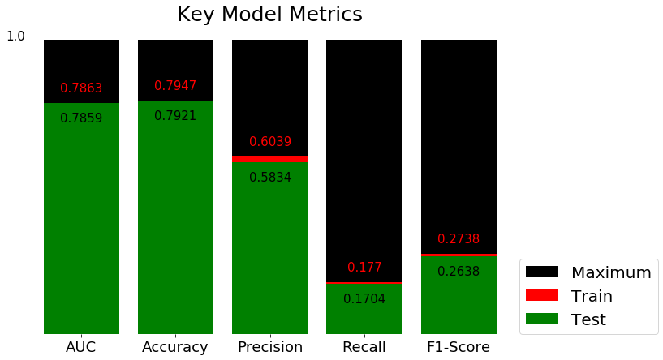

```python
Graph_Model_Metrics(model_results)
```

### First GBT Confusion Matrix:

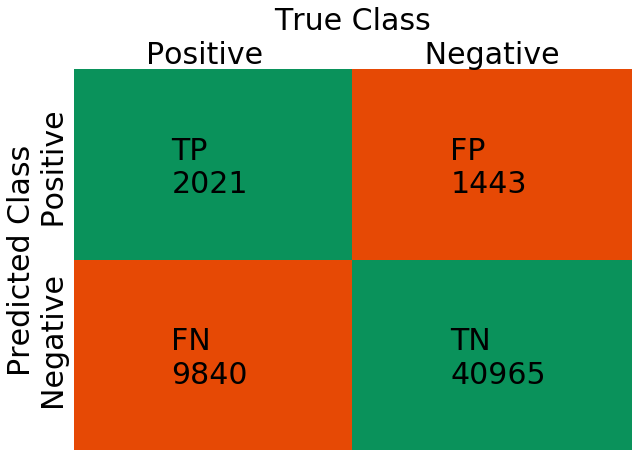

```python
ConfusionMatrix(y_test,GBT_First_Model.predict(X_test))
```

### First GBT ROC Curve:

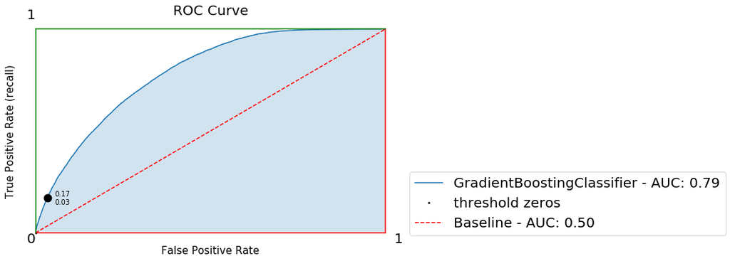

```python
models_list = [calcuate_roc_curve(GBT_First_Model,X_test)]
Graph_AUC(models_list,X_test)
```

## b. Second Gradient Boosting Model:

```python
#Initial Hyperparameters:
n_estimators = 2000
learning_rate = 0.5
max_depth = 5
min_samples_split = 10
min_samples_leaf = 10

#Data
data = (X_train, X_test, y_train, y_test)

#Initial Model
model_results = GBT(data,min_samples_split,min_samples_leaf,n_estimators,learning_rate,max_depth)
model_results = pd.DataFrame([model_results[0]],columns = model_results[1])
GBT_Second_Model = model_results['Model'].values[0]
```

```
480.55991530418396 seconds
```

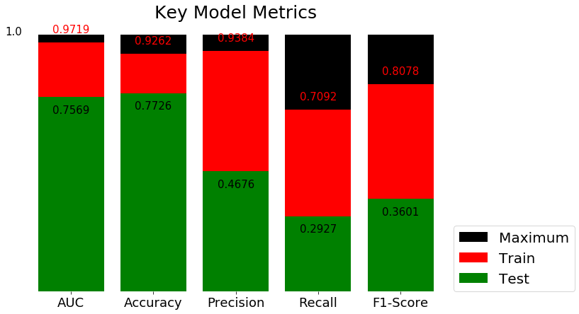

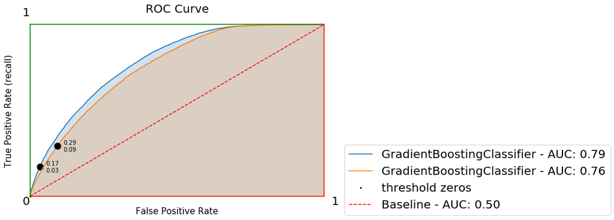

```python
Graph_Model_Metrics(model_results)

models_list = [calcuate_roc_curve(GBT_First_Model,X_test),
               calcuate_roc_curve(GBT_Second_Model,X_test)]
Graph_AUC(models_list,X_test)
```

## c. Third Gradient Boosting Model (via Custom Grid Search):

```python
import random
from tqdm import tqdm
results = []

for I in range(5):
    features = random.choices(X_train.columns, k=30)
    X_train_rand = X_train[features]
    X_test_rand = X_test[features]

    n_estimators = [10,100,1000,2000]
    learning_rate = [1,0.5,0.2,0.02]
    max_depth = [1,1,2,3]
    min_samples_split = 20
    min_samples_leaf = 20

    for n_estimators,learning_rate,max_depth in tqdm(zip(n_estimators,learning_rate,max_depth)):
        model_results = GBT(data,min_samples_split,min_samples_leaf,n_estimators,learning_rate,max_depth)
        results.append(model_results[0])

results = pd.DataFrame(results,columns = model_results[1])
```

```
0it [00:00, ?it/s]
```

```
0.7304778099060059 seconds
```

```
1it [00:01,  1.58s/it]
```

```
6.956040859222412 seconds
```

```
2it [00:10,  3.65s/it]
```

```
107.16527438163757 seconds
```

```
3it [02:05, 37.22s/it]
```

```
262.87870025634766 seconds
```

```
4it [06:51, 102.80s/it]
0it [00:00, ?it/s]
```

```
0.7410156726837158 seconds
```

```
1it [00:01,  1.36s/it]
```

```
6.308323621749878 seconds
```

```
2it [00:08,  3.22s/it]
```

```
91.781414270401 seconds
```

```
3it [01:49, 32.40s/it]
```

```
252.59895205497742 seconds
```

```
4it [06:24, 96.03s/it]
0it [00:00, ?it/s]
```

```
0.8575558662414551 seconds
```

```
1it [00:01,  1.48s/it]
```

```
6.290509223937988 seconds
```

```
2it [00:08,  3.28s/it]
```

```
92.19147229194641 seconds
```

```
3it [01:52, 33.23s/it]
```

```
247.97069668769836 seconds
```

```
4it [06:22, 95.51s/it]
0it [00:00, ?it/s]
```

```
0.707024097442627 seconds
```

```
1it [00:01,  1.34s/it]
```

```
6.283346891403198 seconds
```

```
2it [00:08,  3.17s/it]
```

```
96.05568480491638 seconds
```

```
3it [01:53, 33.57s/it]
```

```
279.07784366607666 seconds
```

```
4it [06:54, 103.66s/it]
0it [00:00, ?it/s]
```

```
0.7212283611297607 seconds
```

```
1it [00:01,  1.35s/it]
```

```
6.142180442810059 seconds
```

```
2it [00:08,  3.18s/it]
```

```
91.41025996208191 seconds
```

```
3it [01:48, 32.23s/it]
```

```
244.84138464927673 seconds
```

```
4it [06:14, 93.62s/it]
```

```python
results.head()
```

|  | Model | Features | Dataset | Target | AUC | Accuracy | Precision | Recall | F1-Score | Frequency | AUC_Delta | Accuracy_Delta | Precision_Delta | Recall_Delta | F1-Score_Delta |
| --- | --- | --- | --- | --- | --- | --- | --- | --- | --- | --- | --- | --- | --- | --- | --- |
| 0 | ([DecisionTreeRegressor(criterion='friedman_ms... | Test | [Coverage_Level_Code, Coverage_Level_Parent, D... | 1 | 0.7173 | 0.7804 | 0.4887 | 0.1036 | 0.1710 | 11861 | 0.0007 | 0.0017 | 0.0193 | 0.0035 | 0.0058 |
| 1 | ([DecisionTreeRegressor(criterion='friedman_ms... | Test | [Coverage_Level_Code, Coverage_Level_Parent, D... | 1 | 0.7704 | 0.7875 | 0.5852 | 0.0949 | 0.1634 | 11861 | -0.0014 | 0.0008 | 0.0120 | 0.0026 | 0.0042 |
| 2 | ([DecisionTreeRegressor(criterion='friedman_ms... | Test | [Coverage_Level_Code, Coverage_Level_Parent, D... | 1 | 0.7919 | 0.7939 | 0.5876 | 0.1905 | 0.2878 | 11861 | 0.0099 | 0.0055 | 0.0363 | 0.0171 | 0.0237 |
| 3 | ([DecisionTreeRegressor(criterion='friedman_ms... | Test | [Coverage_Level_Code, Coverage_Level_Parent, D... | 1 | 0.7910 | 0.7941 | 0.6017 | 0.1708 | 0.2661 | 11861 | 0.0073 | 0.0040 | 0.0319 | 0.0104 | 0.0157 |
| 4 | ([DecisionTreeRegressor(criterion='friedman_ms... | Test | [Coverage_Level_Code, Coverage_Level_Parent, D... | 1 | 0.7173 | 0.7804 | 0.4887 | 0.1036 | 0.1710 | 11861 | 0.0007 | 0.0017 | 0.0193 | 0.0035 | 0.0058 |

```python
modelGridSearch = results.sort_values('Recall',ascending=False).reset_index(drop=True).iloc[0]['Model']
```

```python
columns = ['Model','Features','Dataset', 'Target', 'AUC', 'Accuracy', 'Precision', 'Recall', 'F1-Score',
               'Frequency', 'AUC_Delta','Accuracy_Delta', 'Precision_Delta', 'Recall_Delta','F1-Score_Delta']
model_results = [modelGridSearch] + ConfusionStats(modelGridSearch,X_train, X_test, y_train, y_test).loc[3].tolist()
model_results = pd.DataFrame([model_results],columns = columns)
```

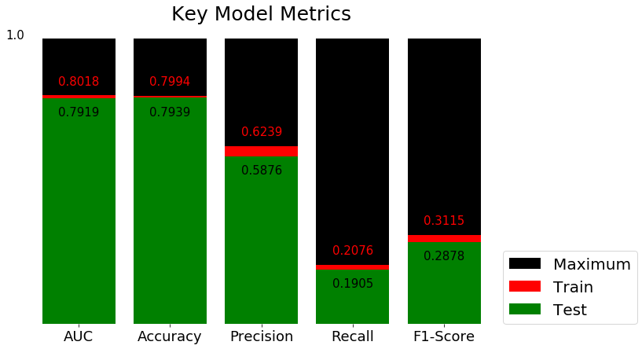

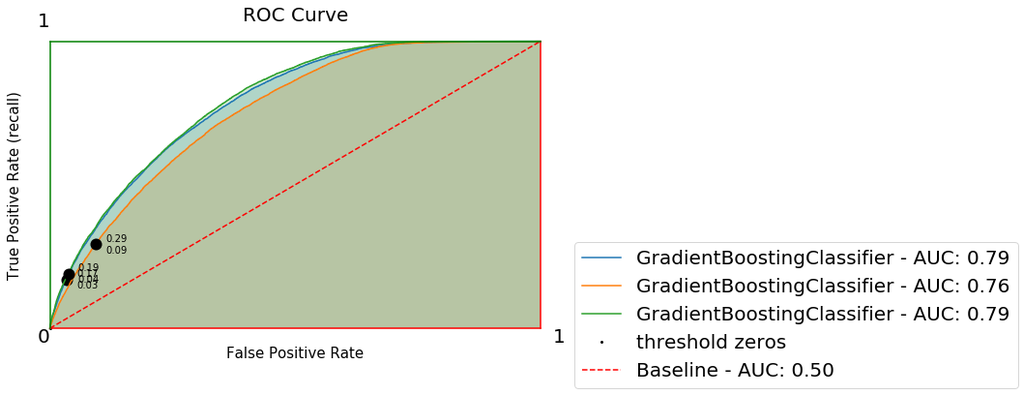

```python
Graph_Model_Metrics(model_results)

models_list = [calcuate_roc_curve(GBT_First_Model,X_test),
               calcuate_roc_curve(GBT_Second_Model,X_test),
               calcuate_roc_curve(modelGridSearch,X_test)]
Graph_AUC(models_list,X_test)
```

Previous Results from Prior Runs:

```python
pd.read_csv('../Project_Data/Model_Project_Data/GBT_Grid_Search.csv').head()
```

|  | Model | Features | Dataset | Target | AUC | Accuracy | Precision | Recall | F1-Score | Frequency | AUC_Delta | Accuracy_Delta | Precision_Delta | Recall_Delta | F1-Score_Delta |
| --- | --- | --- | --- | --- | --- | --- | --- | --- | --- | --- | --- | --- | --- | --- | --- |
| 0 | GradientBoostingClassifier(learning_rate=0.2, ... | Test | ['Renew_Method', 'year', 'Race', 'Auto_In_The_... | 1 | 0.7776 | 0.7898 | 0.5846 | 0.1314 | 0.2146 | 11861 | -0.0020 | 0.0013 | 0.0154 | 0.0020 | 0.0037 |
| 1 | GradientBoostingClassifier(learning_rate=0.2, ... | Test | ['Do_Not_Telemarket', 'ERS_Member_Cost_Three_Y... | 1 | 0.7763 | 0.7914 | 0.5946 | 0.1439 | 0.2317 | 11861 | -0.0013 | 0.0007 | 0.0075 | 0.0009 | 0.0018 |
| 2 | GradientBoostingClassifier(learning_rate=0.2, ... | Test | ['Email_Prefrence_For_At_least_One_Product', '... | 1 | 0.7753 | 0.7893 | 0.5796 | 0.1314 | 0.2143 | 11861 | -0.0014 | 0.0014 | 0.0153 | 0.0022 | 0.0039 |
| 3 | GradientBoostingClassifier(learning_rate=0.2, ... | Test | ['Marital_Status', 'Member_Expiration_Date', '... | 1 | 0.7752 | 0.7906 | 0.5975 | 0.1279 | 0.2107 | 11861 | -0.0015 | 0.0011 | 0.0152 | 0.0000 | 0.0009 |
| 4 | GradientBoostingClassifier(learning_rate=0.5, ... | Test | ['Email_Prefrence_For_At_least_One_Product', '... | 1 | 0.7699 | 0.7873 | 0.5896 | 0.0888 | 0.1543 | 11861 | -0.0023 | 0.0004 | 0.0093 | -0.0020 | -0.0027 |

## 2. Bobby's Models:

```python
df_Auto = pd.read_csv('../Project_Data/Model_Project_Data/AAA_Final_Auto.csv')
```

```python
df_Auto = df_Auto.drop('Coverage_Level_Code.1', axis = 1)
```

```python
target = df_Auto['Auto']
df_Auto = df_Auto.drop('Auto', axis=1)
features = df_Auto
```

```python
X_train, X_test, y_train, y_test = train_test_split(features, target, random_state=42)
```

```python
from sklearn.ensemble import RandomForestClassifier

forest_Auto = RandomForestClassifier(n_estimators=400,
                                random_state=2,
                                max_depth=9,
                                min_samples_split=3,
                                criterion='entropy')
forest_Auto.fit(X_train, y_train)
```

```
RandomForestClassifier(criterion='entropy', max_depth=9, min_samples_split=3,
                       n_estimators=400, random_state=2)
```

|  | Feature | Importance |
| --- | --- | --- |
| 6 | Member_Status | 0.234595 |
| 36 | Member_Dues_Three_Years | 0.108640 |
| 19 | Email_Pref_Your_AAA_Digital | 0.072850 |
| 10 | Count_Clicks_or_Opens | 0.068030 |
| 9 | Renew_Method | 0.054382 |

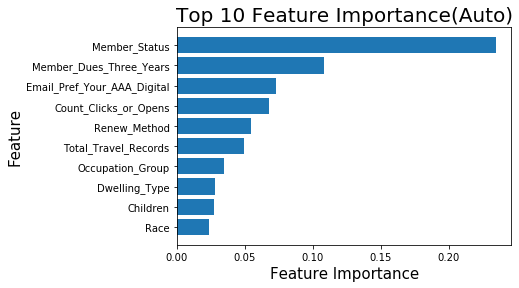

```python
data = importanceDf(features,forest_Auto)

display(data.head())

data = data.sort_values('Importance').tail(10)

barh(data.Feature,data.Importance)

#Labels
xlabel("Feature Importance",size=15)
ylabel("Feature",size=15)
title('Top 10 Feature Importance(Auto)',size=20)
```

```python
prediction_forest_Auto = forest_Auto.predict(X_test)
scoreTest = forest_Auto.score(X_test, y_test)
```

```python
print("Accuracy on training set: {:.3f}".format(forest_Auto.score(X_train, y_train)))
print("Accuracy on test set: {:.3f}".format(forest_Auto.score(X_test, y_test)))
```

```
Accuracy on training set: 0.756
Accuracy on test set: 0.746
```

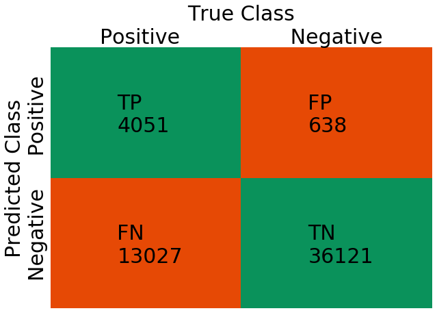

```python
ConfusionMatrix(y_test, prediction_forest_Auto)
```

```python
classification_df(y_test, prediction_forest_Auto)
```

|  | Target | precision | recall | f1-score | support |
| --- | --- | --- | --- | --- | --- |
| 0 | 0 | 0.73 | 0.98 | 0.84 | 36759 |
| 1 | 1 | 0.86 | 0.24 | 0.37 | 17078 |

## 3. Jason's Models:

## Correlation

```python
pd.set_option('display.max_rows',70)
corr = AAA_Combined.corr()['Auto'][:]
corr
```

```
Coverage_Level_Code                         0.107931
Coverage_Level_Parent                       0.104680
Do_Not_Direct_Mail_Solicit                 -0.026388
Do_Not_Send_Publications                   -0.012239
Do_Not_Telemarket                          -0.028302
Member_Expiration_Date                      0.015488
Member_Status                              -0.141303
Member_Tenure_Years                         0.036912
Member_Tenure_Years_Banding                -0.006448
Renew_Method                               -0.101837
Auto                                        1.000000
Home                                        0.603893
Count_Clicks_or_Opens                       0.076521
Auto_In_The_Market_New                      0.024994
Auto_In_The_Market_Used                     0.010688
Children                                    0.063026
Consumerview_Profitability_Score           -0.025790
Credit_RangesDecode                        -0.085091
Dwelling_Type                               0.049182
Education                                   0.010819
Email_Prefrence_For_At_least_One_Product    0.163820
Email_Pref_Your_AAA_Digital                 0.194163
Est_Household_IncomeDecode                 -0.068099
FSV_CMSI_Flag                               0.090746
FSV_Credit_Card_Flag                        0.087009
FSV_ID_Theft_Flag                           0.056171
FSV_TCI_Flag                                0.050095
FSV_TrueCar_Sales_Count                     0.004436
Occupation_Group                           -0.100764
Marital_Status                             -0.038752
Net_Worth                                  -0.071271
Race                                       -0.057959
V12_Auto_Count                              0.038707
TRV_Priceline_Count                         0.029670
Total_Travel_Records                        0.061386
Member_Count                                0.045797
year                                        0.088607
Age                                        -0.011817
Member_Dues_Three_Years                     0.164715
ERS_Member_Cost_Three_Years                 0.061654
ERS_ENT_Count_Three_Years                   0.059730
Name: Auto, dtype: float64
```

```python
AAA_Combined.columns
```

```
Index(['Coverage_Level_Code', 'Coverage_Level_Parent',
       'Do_Not_Direct_Mail_Solicit', 'Do_Not_Send_Publications',
       'Do_Not_Telemarket', 'Member_Expiration_Date', 'Member_Status',
       'Member_Tenure_Years', 'Member_Tenure_Years_Banding', 'Renew_Method',
       'Auto', 'Home', 'Count_Clicks_or_Opens', 'Auto_In_The_Market_New',
       'Auto_In_The_Market_Used', 'Children',
       'Consumerview_Profitability_Score', 'Credit_RangesDecode',
       'Dwelling_Type', 'Education',
       'Email_Prefrence_For_At_least_One_Product',
       'Email_Pref_Your_AAA_Digital', 'Est_Household_IncomeDecode',
       'FSV_CMSI_Flag', 'FSV_Credit_Card_Flag', 'FSV_ID_Theft_Flag',
       'FSV_TCI_Flag', 'FSV_TrueCar_Sales_Count', 'Occupation_Group',
       'Marital_Status', 'Net_Worth', 'Race', 'V12_Auto_Count',
       'TRV_Priceline_Count', 'Total_Travel_Records', 'Member_Count', 'year',
       'Age', 'Member_Dues_Three_Years', 'ERS_Member_Cost_Three_Years',
       'ERS_ENT_Count_Three_Years'],
      dtype='object')
```

## Narrowing Features Down From Correlation

```python
filtered_df=AAA_Combined[['Coverage_Level_Code', 'Coverage_Level_Parent',
'Member_Status', 'Renew_Method','Count_Clicks_or_Opens', 'Children',
'Credit_RangesDecode', 'Dwelling_Type',
       'Email_Prefrence_For_At_least_One_Product',
       'Email_Pref_Your_AAA_Digital', 'Est_Household_IncomeDecode',
       'FSV_CMSI_Flag', 'FSV_Credit_Card_Flag', 'FSV_ID_Theft_Flag',
       'FSV_TCI_Flag', 'Occupation_Group', 'Net_Worth', 'Race', 'Member_Dues_Three_Years', 'ERS_Member_Cost_Three_Years',
       'ERS_ENT_Count_Three_Years']]
```

```python
X_train, X_test, y_train, y_test = train_test_split(filtered_df, AAA_Combined['Auto'], train_size=0.7, random_state=42)
```

```python
X_train
```

|  | Coverage_Level_Code | Coverage_Level_Parent | Member_Status | Renew_Method | Count_Clicks_or_Opens | Children | Credit_RangesDecode | Dwelling_Type | Email_Prefrence_For_At_least_One_Product | Email_Pref_Your_AAA_Digital | ... | FSV_CMSI_Flag | FSV_Credit_Card_Flag | FSV_ID_Theft_Flag | FSV_TCI_Flag | Occupation_Group | Net_Worth | Race | Member_Dues_Three_Years | ERS_Member_Cost_Three_Years | ERS_ENT_Count_Three_Years |
| --- | --- | --- | --- | --- | --- | --- | --- | --- | --- | --- | --- | --- | --- | --- | --- | --- | --- | --- | --- | --- | --- |
| 165257 | 0 | 0 | 2 | 1 | 19.0 | 2 | 4 | 3 | 0 | 2 | ... | 0 | 0 | 0 | 0 | 12 | 2 | 14 | 158.00 | 0.00 | 0.0 |
| 120641 | 3 | 1 | 1 | 1 | 0.0 | 0 | 8 | 0 | 0 | 0 | ... | 0 | 0 | 0 | 0 | 0 | 9 | 20 | 161.00 | 0.00 | 0.0 |
| 88026 | 0 | 0 | 1 | 1 | 0.0 | 0 | 8 | 0 | 0 | 0 | ... | 0 | 0 | 0 | 0 | 18 | 9 | 20 | 109.00 | 0.00 | 0.0 |
| 132856 | 3 | 1 | 0 | 0 | 0.0 | 2 | 6 | 3 | 0 | 0 | ... | 1 | 0 | 0 | 0 | 10 | 4 | 10 | 143.96 | 127.00 | 4.0 |
| 98958 | 0 | 0 | 1 | 1 | 0.0 | 1 | 5 | 1 | 0 | 0 | ... | 0 | 0 | 0 | 0 | 11 | 7 | 18 | 161.00 | 0.00 | 0.0 |
| ... | ... | ... | ... | ... | ... | ... | ... | ... | ... | ... | ... | ... | ... | ... | ... | ... | ... | ... | ... | ... | ... |
| 119879 | 0 | 0 | 2 | 1 | 0.0 | 0 | 8 | 0 | 1 | 2 | ... | 0 | 0 | 0 | 0 | 8 | 9 | 20 | 153.00 | 0.00 | 0.0 |
| 103694 | 3 | 1 | 0 | 1 | 15.0 | 2 | 5 | 3 | 0 | 2 | ... | 0 | 0 | 0 | 0 | 18 | 8 | 16 | 260.00 | 540.02 | 4.0 |
| 131932 | 3 | 1 | 0 | 0 | 0.0 | 1 | 5 | 3 | 0 | 0 | ... | 1 | 0 | 0 | 0 | 15 | 2 | 11 | 260.00 | 0.00 | 0.0 |
| 146867 | 3 | 1 | 2 | 1 | 0.0 | 1 | 5 | 3 | 0 | 0 | ... | 0 | 0 | 0 | 0 | 12 | 7 | 15 | 171.00 | 0.00 | 0.0 |
| 121958 | 3 | 1 | 1 | 1 | 0.0 | 0 | 8 | 0 | 0 | 0 | ... | 0 | 0 | 0 | 0 | 18 | 9 | 20 | 161.00 | 71.50 | 2.0 |

151952 rows × 21 columns

# Logistic Regression Loop

### In this section, a loop will be utilized to find the optimal logistic regression. The data was split 70-30. The parameters are a list of features and desired number of features out of that list. The loop then returns both the highest test set accuracy and the features needed to achieve that.

```python
import itertools
from sklearn.linear_model import LogisticRegression
from sklearn import metrics
import time
def create_lists(complete_list_of_elements,desired_elements):
    if desired_elements > len(complete_list_of_elements):
        print ("ERROR ==> desired elements is longer that the lenght of the list")
        return None

    all_lists = itertools.combinations(complete_list_of_elements,desired_elements)
    temp_list = [",".join(index) for index in all_lists]

    list_to_be_returned = []

    for current_list in temp_list:
        split_list = current_list.split(",")
        list_to_be_returned.append(split_list)

    print ("Total models: {}".format(len(list_to_be_returned)))
    return list_to_be_returned


model_features = create_lists(['Coverage_Level_Code', 'Coverage_Level_Parent',
'Member_Status', 'Renew_Method','Count_Clicks_or_Opens', 'Children',
'Credit_RangesDecode', 'Dwelling_Type',
'Email_Prefrence_For_At_least_One_Product',
'Email_Pref_Your_AAA_Digital', 'Est_Household_IncomeDecode',
'FSV_CMSI_Flag', 'FSV_Credit_Card_Flag', 'FSV_ID_Theft_Flag',
'FSV_TCI_Flag', 'Occupation_Group', 'Net_Worth', 'Race', 'Member_Dues_Three_Years', 'ERS_Member_Cost_Three_Years',
       'ERS_ENT_Count_Three_Years'],20)

accuracy_to_featues = {}

counter = 0
for current_model in model_features:
    X_train, X_test, y_train, y_test = train_test_split(filtered_df[current_model], AAA_Combined['Auto'], train_size=0.7, random_state=0)
    start = time.time()
    LogReg = LogisticRegression(max_iter=10000)
    LogReg.fit(X_train, y_train)
    y_pred = LogReg.predict(X_test)
    print(f"{time.time() - start} seconds")
    acc_logreg = metrics.accuracy_score(y_test,y_pred) * 100
    acc_logreg
    accuracy_to_featues[acc_logreg] = current_model
    counter+=1
    print("[{}/{}] models trained, accuracy: {}".format(counter,len(model_features),acc_logreg))


highest_scores = max(list(accuracy_to_featues.keys()))

print('')

highest_score_features = accuracy_to_featues[highest_scores]
print(highest_scores,highest_score_features)
```

```
Total models: 21
45.05474829673767 seconds
[1/21] models trained, accuracy: 78.11218770634031
47.22838473320007 seconds
[2/21] models trained, accuracy: 78.08608325783517
25.616267442703247 seconds
[3/21] models trained, accuracy: 78.19203660765014
43.13899207115173 seconds
[4/21] models trained, accuracy: 78.08301214624633
41.997771978378296 seconds
[5/21] models trained, accuracy: 78.0737988114798
45.07241082191467 seconds
[6/21] models trained, accuracy: 78.08301214624633
50.41086483001709 seconds
[7/21] models trained, accuracy: 78.05383658615236
47.63528656959534 seconds
[8/21] models trained, accuracy: 78.07533436727422
51.74553632736206 seconds
[9/21] models trained, accuracy: 78.03848102820817
49.839295864105225 seconds
[10/21] models trained, accuracy: 78.02158991446954
51.61732578277588 seconds
[11/21] models trained, accuracy: 78.08608325783517
52.5722975730896 seconds
[12/21] models trained, accuracy: 78.0952965926017
54.54144597053528 seconds
[13/21] models trained, accuracy: 77.99855657755325
45.1991491317749 seconds
[14/21] models trained, accuracy: 78.08761881362959
51.17128348350525 seconds
[15/21] models trained, accuracy: 78.02312547026396
40.39036750793457 seconds
[16/21] models trained, accuracy: 78.0645854767133
39.04069924354553 seconds
[17/21] models trained, accuracy: 78.11065215054589
46.45564293861389 seconds
[18/21] models trained, accuracy: 78.08301214624633
50.392254114151 seconds
[19/21] models trained, accuracy: 78.0261965818528
49.44309687614441 seconds
[20/21] models trained, accuracy: 78.10297437157378
48.702269077301025 seconds
[21/21] models trained, accuracy: 78.08147659045191

78.19203660765014 ['Coverage_Level_Code', 'Coverage_Level_Parent', 'Member_Status', 'Renew_Method', 'Count_Clicks_or_Opens', 'Children', 'Credit_RangesDecode', 'Dwelling_Type', 'Email_Prefrence_For_At_least_One_Product', 'Email_Pref_Your_AAA_Digital', 'Est_Household_IncomeDecode', 'FSV_CMSI_Flag', '…
```

# Best Logistic Regression

### After looking at the recall and precision, this model is not as good as the others. It is decent at predicting 0s, but bad at predicting 1s

```python
X_train, X_test, y_train, y_test = train_test_split(filtered_df[['Coverage_Level_Code', 'Coverage_Level_Parent', 'Member_Status', 'Renew_Method', 'Count_Clicks_or_Opens', 'Children', 'Credit_RangesDecode', 'Dwelling_Type', 'Email_Prefrence_For_At_least_One_Product', 'Email_Pref_Your_AAA_Digital', 'Est_Household_IncomeDecode', 'FSV_CMSI_Flag', 'FSV_Credit_Card_Flag', 'FSV_ID_Theft_Flag', 'FSV_TCI_Flag', 'Occupation_Group', 'Net_Worth', 'Race', 'ERS_Member_Cost_Three_Years', 'ERS_ENT_Count_Three_Years']], AAA_Combined['Auto'], train_size=0.7, random_state=42)
```

```python
LogReg = LogisticRegression(max_iter=10000)
LogReg.fit(X_train, y_train)
y_pred = LogReg.predict(X_test)
acc_logreg = metrics.accuracy_score(y_test,y_pred) * 100
acc_logreg
```

```
78.16439660335058
```

## Metrics

```python
classification_df(y_test, y_pred)
```

|  | Target | precision | recall | f1-score | support |
| --- | --- | --- | --- | --- | --- |
| 0 | 0 | 0.79 | 0.98 | 0.88 | 50908 |
| 1 | 1 | 0.50 | 0.06 | 0.11 | 14215 |

## Confusion Matrix

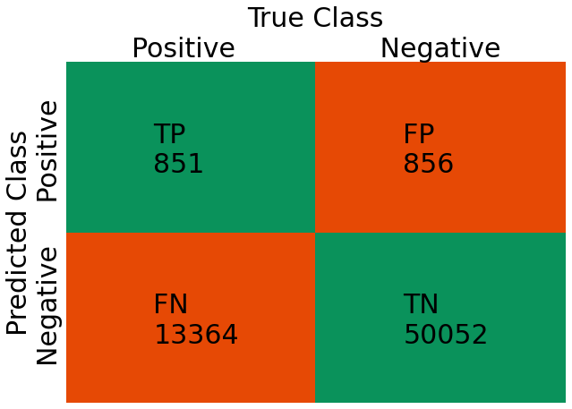

```python
ConfusionMatrix(y_test, y_pred)
```

## Area Under Curve

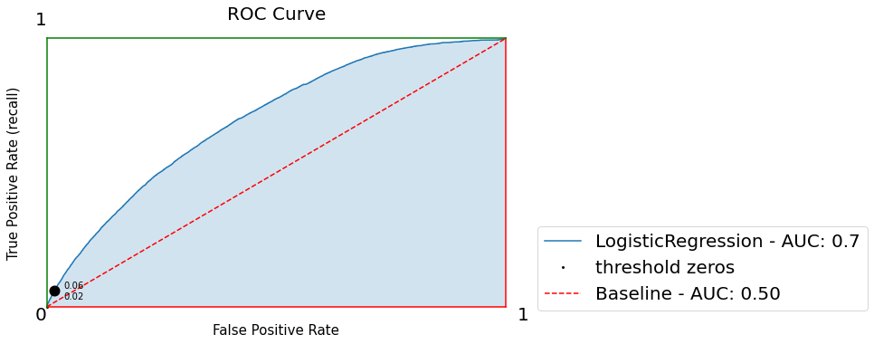

```python
models_list = [calcuate_roc_curve(LogReg,X_test)]
Graph_AUC(models_list,X_test)
```

```python
features = filtered_df[[col for col in filtered_df.columns]]
importanceDfCoef(features,LogReg).head()
```

[output not shown]

## 4. Nate's Models:

```python
df = pd.read_csv("../Project_Data/Model_Project_Data/AAA_Final_Auto.csv")
df = df.drop(["Coverage_Level_Code.1"],axis=1)

y = df[['Auto']]
X = df[[col for col in df.columns if col not in y.columns]]
```

# data prep

```python
from sklearn.model_selection import train_test_split
x_train,x_test,y_train,y_test=train_test_split(X,y,test_size=0.3,random_state=9) #70% training and 30% for testing
```

```python
parameters = {'criterion':('gini', 'entropy'), 'max_depth':[2,4,6,8,10,12,14,16], 'min_samples_leaf':[1,2,3,4,5,6,7,8], 'max_features':("auto", "sqrt", "log2"), 'random_state': [0,1,2,3,4]}
```

```python
from sklearn.model_selection import GridSearchCV
from sklearn.tree import DecisionTreeClassifier

# get the model running
model_auto = DecisionTreeClassifier()
tuning = GridSearchCV(estimator = model_auto, param_grid = parameters, scoring = 'r2')

#sort by the best results
betterModelAuto = tuning.fit(x_train, y_train)
tuning.best_params_, tuning.best_score_
```

```
({'criterion': 'gini',
  'max_depth': 14,
  'max_features': 'log2',
  'min_samples_leaf': 4,
  'random_state': 1},
 -0.26094423201947164)
```

```python
model_auto = DecisionTreeClassifier(criterion= 'entropy', max_depth= 14, max_features = "log2", min_samples_leaf= 2, random_state= 1)
model_auto.fit(x_train, y_train)
treePredAuto = model_auto.predict(x_test)
```

## visuals

```python
def classification_df(y_test, treePred):
    # classification Report
    from sklearn.metrics import classification_report
    cols = ['Target'] + [col for col in [row for row in classification_report(y_test, treePred).split("\n")][0].strip().split("  ") if col != '']
    classification_df = pd.DataFrame([row.strip().split('     ') for row in classification_report(y_test, treePred).split("\n")[2:4]],columns=cols)
    return classification_df
def importanceDf(features,model):
    return pd.DataFrame([[C,I] for C,I in zip(features.columns,model.feature_importances_)],columns = ['Feature','Importance']).sort_values('Importance',ascending=False)
```

```python
classification_df(y_test, treePredAuto)
```

|  | Target | precision | recall | f1-score | support |
| --- | --- | --- | --- | --- | --- |
| 0 | 0 | 0.75 | 0.90 | 0.82 | 44342 |
| 1 | 1 | 0.62 | 0.34 | 0.44 | 20262 |

```python
importanceDf(X,model_auto).head()
```

|  | Feature | Importance |
| --- | --- | --- |
| 6 | Member_Status | 0.215966 |
| 10 | Count_Clicks_or_Opens | 0.079446 |
| 36 | Member_Dues_Three_Years | 0.052820 |
| 19 | Email_Pref_Your_AAA_Digital | 0.047331 |
| 5 | Member_Expiration_Date | 0.046812 |

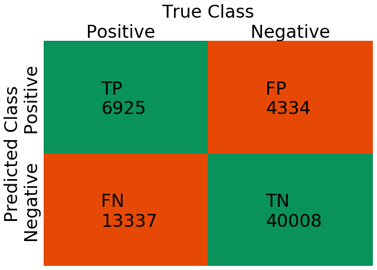

```python
ConfusionMatrix(y_test,treePredAuto)
```

# Modeling Approach & Evaluation for Home Target Value:

## Split Dataset with Home Target Value:

```python
X_train, X_test, y_train, y_test = train_test_split(features, target['Home'], random_state=42)
```

## 1. Luke's Models:

## 1st GBT:

```python
#Initial Hyperparameters:
n_estimators = 1000
learning_rate = 1
max_depth = 10
min_samples_split = 10
min_samples_leaf = 10

#Data
data = (X_train, X_test, y_train, y_test)

#Initial Model
model_results = GBT(data,min_samples_split,min_samples_leaf,n_estimators,learning_rate,max_depth)
model_results = pd.DataFrame([model_results[0]],columns = model_results[1])
GBT_First_Model = model_results['Model'].values[0]
```

```
435.97082328796387 seconds
```

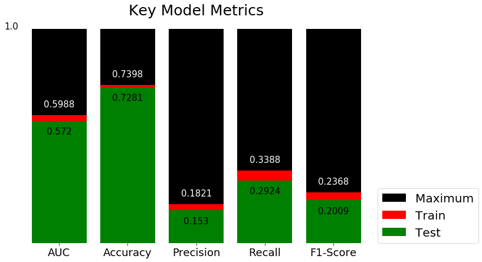

```python
Graph_Model_Metrics(model_results)
```

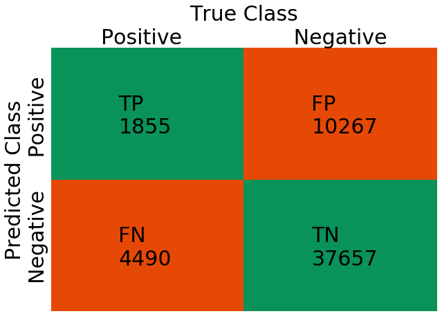

```python
ConfusionMatrix(y_test,GBT_First_Model.predict(X_test))
```

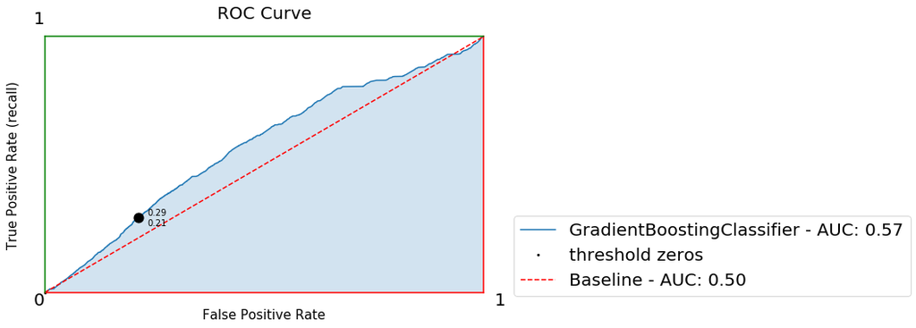

```python
models_list = [calcuate_roc_curve(GBT_First_Model,X_test)]
Graph_AUC(models_list,X_test)
```

## 2nd GBT:

```python
#Initial Hyperparameters:
n_estimators = 2000
learning_rate = 0.5
max_depth = 5
min_samples_split = 10
min_samples_leaf = 10

#Data
data = (X_train, X_test, y_train, y_test)

#Initial Model
model_results = GBT(data,min_samples_split,min_samples_leaf,n_estimators,learning_rate,max_depth)
model_results = pd.DataFrame([model_results[0]],columns = model_results[1])
GBT_Second_Model = model_results['Model'].values[0]
```

```
334.6188175678253 seconds
```

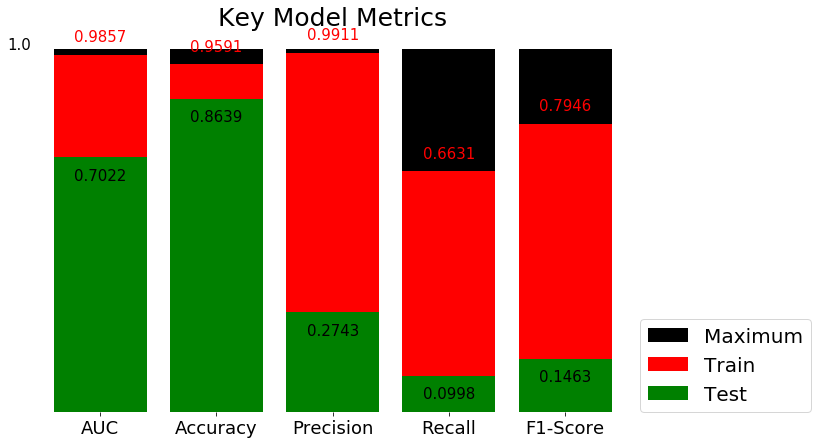

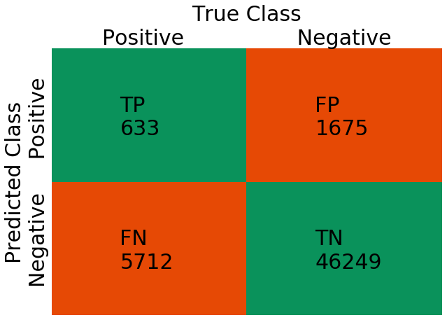

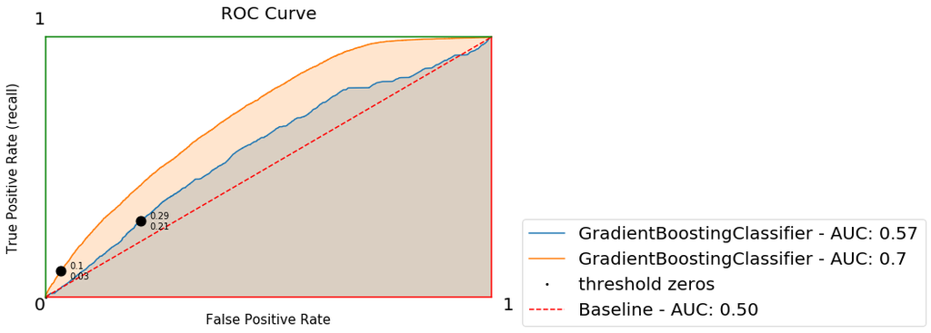

```python
Graph_Model_Metrics(model_results)
ConfusionMatrix(y_test,GBT_Second_Model.predict(X_test))
models_list = [calcuate_roc_curve(GBT_First_Model,X_test),calcuate_roc_curve(GBT_Second_Model,X_test)]
Graph_AUC(models_list,X_test)
```

## 3rd GBT:

```python
#Initial Hyperparameters:
n_estimators = 3000
learning_rate = 0.5
max_depth = 6
min_samples_split = 10
min_samples_leaf = 10

#Data
data = (X_train, X_test, y_train, y_test)

#Initial Model
model_results = GBT(data,min_samples_split,min_samples_leaf,n_estimators,learning_rate,max_depth)
model_results = pd.DataFrame([model_results[0]],columns = model_results[1])
GBT_Third_Model = model_results['Model'].values[0]
```

```
812.2241880893707 seconds
```

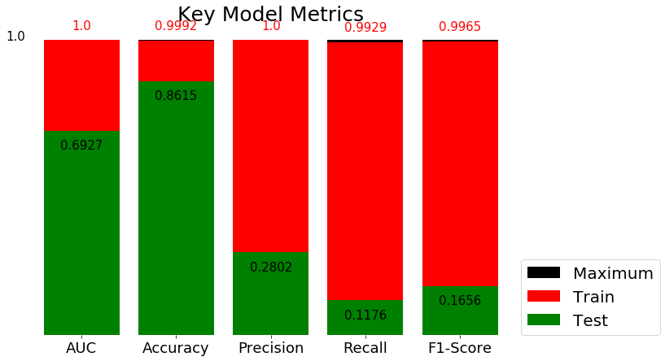

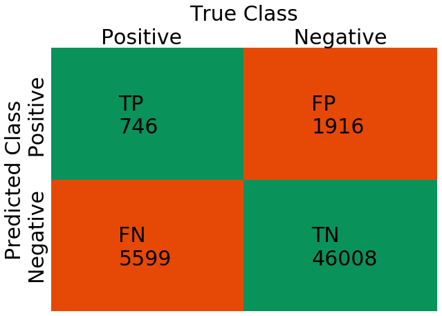

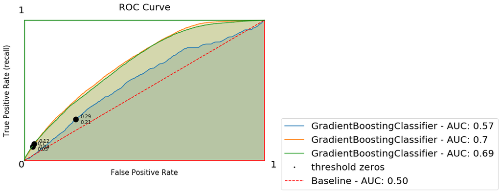

```python
Graph_Model_Metrics(model_results)
ConfusionMatrix(y_test,GBT_Third_Model.predict(X_test))
models_list = [calcuate_roc_curve(GBT_First_Model,X_test),
               calcuate_roc_curve(GBT_Second_Model,X_test),
               calcuate_roc_curve(GBT_Third_Model,X_test)]
Graph_AUC(models_list,X_test)
```

## 2. Bobby's Models:

```python
df_Home = pd.read_csv('../Project_Data/Model_Project_Data/AAA_Final_Home.csv')
```

```python
df_Home = df_Home.drop('Coverage_Level_Code.1', axis = 1)
```

```python
target = df_Home['Home']
df_Home = df_Home.drop('Home', axis=1)
features = df_Home
```

```python
X_train, X_test, y_train, y_test = train_test_split(features, target, random_state=42)
```

```python
forest4 = RandomForestClassifier(n_estimators=400,
                                random_state=2,
                                max_depth=9,
                                min_samples_split=3,
                                criterion='entropy')
forest4.fit(X_train, y_train)
```

```
RandomForestClassifier(criterion='entropy', max_depth=9, min_samples_split=3,
                       n_estimators=400, random_state=2)
```

```python
prediction_forest4 = forest4.predict(X_test)
scoreTest = forest4.score(X_test, y_test)
```

|  | Feature | Importance |
| --- | --- | --- |
| 6 | Member_Status | 0.117397 |
| 30 | V12_Auto_Count | 0.104134 |
| 32 | Total_Travel_Records | 0.094549 |
| 9 | Renew_Method | 0.080497 |
| 10 | Count_Clicks_or_Opens | 0.078652 |

[figure not shown]

```python
data = importanceDf(features,forest4)

display(data.head())

data = data.sort_values('Importance').tail(10)

barh(data.Feature,data.Importance)

#Labels
xlabel("Feature Importance",size=15)
ylabel("Feature",size=15)
title('Top 10 Feature Importance(Auto)',size=20)
```

```python
print("Accuracy on training set: {:.3f}".format(forest4.score(X_train, y_train)))
print("Accuracy on test set: {:.3f}".format(forest4.score(X_test, y_test)))
```

```
Accuracy on training set: 0.836
Accuracy on test set: 0.835
```

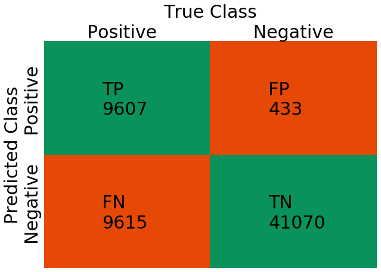

```python
ConfusionMatrix(y_test, prediction_forest4)
```

```python
classification_df(y_test, prediction_forest4)
```

|  | Target | precision | recall | f1-score | support |
| --- | --- | --- | --- | --- | --- |
| 0 | 0 | 0.81 | 0.99 | 0.89 | 41503 |
| 1 | 1 | 0.96 | 0.50 | 0.66 | 19222 |

## 3. Jason's Models:

## Correlation

### The first step is to check correlation. For my loop, I decided to only go with fields that had a correlation of .05 or higher.

```python
pd.set_option('display.max_rows',70)
corr = AAA_Combined.corr()['Home'][:]
corr
```

```
Coverage_Level_Code                         0.068085
Coverage_Level_Parent                       0.065785
Do_Not_Direct_Mail_Solicit                 -0.020640
Do_Not_Send_Publications                   -0.008009
Do_Not_Telemarket                          -0.022609
Member_Expiration_Date                      0.010999
Member_Status                              -0.102688
Member_Tenure_Years                         0.050350
Member_Tenure_Years_Banding                -0.010226
Renew_Method                               -0.078461
Auto                                        0.603893
Home                                        1.000000
Count_Clicks_or_Opens                       0.080714
Auto_In_The_Market_New                      0.003916
Auto_In_The_Market_Used                     0.005679
Children                                    0.064576
Consumerview_Profitability_Score           -0.015178
Credit_RangesDecode                        -0.068983
Dwelling_Type                               0.053057
Education                                   0.006779
Email_Prefrence_For_At_least_One_Product    0.042953
Email_Pref_Your_AAA_Digital                 0.115790
Est_Household_IncomeDecode                 -0.039233
FSV_CMSI_Flag                               0.073298
FSV_Credit_Card_Flag                        0.074243
FSV_ID_Theft_Flag                           0.060260
FSV_TCI_Flag                                0.040249
FSV_TrueCar_Sales_Count                     0.009010
Occupation_Group                           -0.072888
Marital_Status                             -0.050590
Net_Worth                                  -0.068580
Race                                       -0.061730
V12_Auto_Count                              0.047490
TRV_Priceline_Count                         0.030469
Total_Travel_Records                        0.060134
Member_Count                                0.018912
year                                        0.058391
Age                                        -0.017248
Member_Dues_Three_Years                     0.107392
ERS_Member_Cost_Three_Years                 0.021591
ERS_ENT_Count_Three_Years                   0.018552
Name: Home, dtype: float64
```

```python
AAA_Combined.columns
```

```
Index(['Coverage_Level_Code', 'Coverage_Level_Parent',
       'Do_Not_Direct_Mail_Solicit', 'Do_Not_Send_Publications',
       'Do_Not_Telemarket', 'Member_Expiration_Date', 'Member_Status',
       'Member_Tenure_Years', 'Member_Tenure_Years_Banding', 'Renew_Method',
       'Auto', 'Home', 'Count_Clicks_or_Opens', 'Auto_In_The_Market_New',
       'Auto_In_The_Market_Used', 'Children',
       'Consumerview_Profitability_Score', 'Credit_RangesDecode',
       'Dwelling_Type', 'Education',
       'Email_Prefrence_For_At_least_One_Product',
       'Email_Pref_Your_AAA_Digital', 'Est_Household_IncomeDecode',
       'FSV_CMSI_Flag', 'FSV_Credit_Card_Flag', 'FSV_ID_Theft_Flag',
       'FSV_TCI_Flag', 'FSV_TrueCar_Sales_Count', 'Occupation_Group',
       'Marital_Status', 'Net_Worth', 'Race', 'V12_Auto_Count',
       'TRV_Priceline_Count', 'Total_Travel_Records', 'Member_Count', 'year',
       'Age', 'Member_Dues_Three_Years', 'ERS_Member_Cost_Three_Years',
       'ERS_ENT_Count_Three_Years'],
      dtype='object')
```

## Narrowing Features Down From Correlation

```python
filtered_df=AAA_Combined[['Coverage_Level_Code', 'Coverage_Level_Parent', 'Member_Status',
       'Member_Tenure_Years', 'Renew_Method', 'Count_Clicks_or_Opens', 'Children',
        'Credit_RangesDecode','Dwelling_Type', 'Email_Pref_Your_AAA_Digital','FSV_CMSI_Flag', 'FSV_Credit_Card_Flag',
        'FSV_ID_Theft_Flag', 'Occupation_Group','Marital_Status', 'Net_Worth', 'Race', 'Total_Travel_Records', 'year',
        'Member_Dues_Three_Years']]
```

```python
X_train, X_test, y_train, y_test = train_test_split(filtered_df, AAA_Combined['Home'], train_size=0.7, random_state=42)
```

```python
X_train
```

|  | Coverage_Level_Code | Coverage_Level_Parent | Member_Status | Member_Tenure_Years | Renew_Method | Count_Clicks_or_Opens | Children | Credit_RangesDecode | Dwelling_Type | Email_Pref_Your_AAA_Digital | FSV_CMSI_Flag | FSV_Credit_Card_Flag | FSV_ID_Theft_Flag | Occupation_Group | Marital_Status | Net_Worth | Race | Total_Travel_Records | year | Member_Dues_Three_Years |
| --- | --- | --- | --- | --- | --- | --- | --- | --- | --- | --- | --- | --- | --- | --- | --- | --- | --- | --- | --- | --- |
| 165257 | 0 | 0 | 2 | 6 | 1 | 19.0 | 2 | 4 | 3 | 2 | 0 | 0 | 0 | 12 | 0 | 2 | 14 | 1.0 | 1954 | 158.00 |
| 120641 | 3 | 1 | 1 | 14 | 1 | 0.0 | 0 | 8 | 0 | 0 | 0 | 0 | 0 | 0 | 2 | 9 | 20 | 0.0 | 1989 | 161.00 |
| 88026 | 0 | 0 | 1 | 4 | 1 | 0.0 | 0 | 8 | 0 | 0 | 0 | 0 | 0 | 18 | 2 | 9 | 20 | 0.0 | 1994 | 109.00 |
| 132856 | 3 | 1 | 0 | 1 | 0 | 0.0 | 2 | 6 | 3 | 0 | 1 | 0 | 0 | 10 | 1 | 4 | 10 | 0.0 | 1958 | 143.96 |
| 98958 | 0 | 0 | 1 | 7 | 1 | 0.0 | 1 | 5 | 1 | 0 | 0 | 0 | 0 | 11 | 1 | 7 | 18 | 0.0 | 1976 | 161.00 |
| ... | ... | ... | ... | ... | ... | ... | ... | ... | ... | ... | ... | ... | ... | ... | ... | ... | ... | ... | ... | ... |
| 119879 | 0 | 0 | 2 | 3 | 1 | 0.0 | 0 | 8 | 0 | 2 | 0 | 0 | 0 | 8 | 2 | 9 | 20 | 0.0 | 1990 | 153.00 |
| 103694 | 3 | 1 | 0 | 9 | 1 | 15.0 | 2 | 5 | 3 | 2 | 0 | 0 | 0 | 18 | 1 | 8 | 16 | 0.0 | 1958 | 260.00 |
| 131932 | 3 | 1 | 0 | 22 | 0 | 0.0 | 1 | 5 | 3 | 0 | 1 | 0 | 0 | 15 | 2 | 2 | 11 | 0.0 | 1950 | 260.00 |
| 146867 | 3 | 1 | 2 | 20 | 1 | 0.0 | 1 | 5 | 3 | 0 | 0 | 0 | 0 | 12 | 1 | 7 | 15 | 0.0 | 1952 | 171.00 |
| 121958 | 3 | 1 | 1 | 14 | 1 | 0.0 | 0 | 8 | 0 | 0 | 0 | 0 | 0 | 18 | 2 | 9 | 20 | 0.0 | 1974 | 161.00 |

151952 rows × 20 columns

# Logistic Regression Loop

### In this section, a loop will be utilized to find the optimal logistic regression. The data was split 70-30. The parameters are a list of features and desired number of features out of that list. The loop then returns both the highest test set accuracy and the features needed to achieve that.

```python
import itertools
from sklearn.linear_model import LogisticRegression
from sklearn import metrics
import time
def create_lists(complete_list_of_elements,desired_elements):
    if desired_elements > len(complete_list_of_elements):
        print ("ERROR ==> desired elements is longer that the lenght of the list")
        return None

    all_lists = itertools.combinations(complete_list_of_elements,desired_elements)
    temp_list = [",".join(index) for index in all_lists]

    list_to_be_returned = []

    for current_list in temp_list:
        split_list = current_list.split(",")
        list_to_be_returned.append(split_list)

    print ("Total models: {}".format(len(list_to_be_returned)))
    return list_to_be_returned


model_features = create_lists(['Coverage_Level_Code', 'Coverage_Level_Parent', 'Member_Status',
       'Member_Tenure_Years', 'Renew_Method', 'Count_Clicks_or_Opens', 'Children',
        'Credit_RangesDecode','Dwelling_Type', 'Email_Pref_Your_AAA_Digital','FSV_CMSI_Flag', 'FSV_Credit_Card_Flag',
        'FSV_ID_Theft_Flag', 'Occupation_Group','Marital_Status', 'Net_Worth', 'Race', 'Total_Travel_Records', 'year',
        'Member_Dues_Three_Years'],19)

accuracy_to_featues = {}

counter = 0
for current_model in model_features:
    X_train, X_test, y_train, y_test = train_test_split(filtered_df[current_model], AAA_Combined['Home'], train_size=0.7, random_state=0)
    start = time.time()
    LogReg = LogisticRegression(max_iter=10000)
    LogReg.fit(X_train, y_train)
    y_pred = LogReg.predict(X_test)
    print(f"{time.time() - start} seconds")
    acc_logreg = metrics.accuracy_score(y_test,y_pred) * 100
    acc_logreg
    accuracy_to_featues[acc_logreg] = current_model
    counter+=1
    print("[{}/{}] models trained, accuracy: {}".format(counter,len(model_features),acc_logreg))


highest_scores = max(list(accuracy_to_featues.keys()))

print('')

highest_score_features = accuracy_to_featues[highest_scores]
print(highest_scores,highest_score_features)
```

```
Total models: 20
35.670340061187744 seconds
[1/20] models trained, accuracy: 88.14243815549038
37.736409187316895 seconds
[2/20] models trained, accuracy: 88.13015370913502
54.590471506118774 seconds
[3/20] models trained, accuracy: 88.1132625953964
42.675660848617554 seconds
[4/20] models trained, accuracy: 88.07640925633032
28.532093286514282 seconds
[5/20] models trained, accuracy: 88.1132625953964
36.3652126789093 seconds
[6/20] models trained, accuracy: 88.13936704390154
38.805174112319946 seconds
[7/20] models trained, accuracy: 88.11479815119083
24.032500982284546 seconds
[8/20] models trained, accuracy: 88.13322482072387
24.033724308013916 seconds
[9/20] models trained, accuracy: 88.12401148595734
20.794947862625122 seconds
[10/20] models trained, accuracy: 88.13322482072387
20.752697944641113 seconds
[11/20] models trained, accuracy: 88.1209403743685
20.225638389587402 seconds
[12/20] models trained, accuracy: 88.12708259754618
53.223177671432495 seconds
[13/20] models trained, accuracy: 88.14243815549038
56.44932293891907 seconds
[14/20] models trained, accuracy: 88.12708259754618
16.496050596237183 seconds
[15/20] models trained, accuracy: 88.1286181533406
25.33061194419861 seconds
[16/20] models trained, accuracy: 88.1286181533406
40.4749960899353 seconds
[17/20] models trained, accuracy: 88.10558481642431
49.95191788673401 seconds
[18/20] models trained, accuracy: 88.10404926062988
23.980117321014404 seconds
[19/20] models trained, accuracy: 88.12401148595734
30.738491535186768 seconds
[20/20] models trained, accuracy: 88.09944259324662

88.14243815549038 ['Coverage_Level_Code', 'Coverage_Level_Parent', 'Member_Status', 'Member_Tenure_Years', 'Renew_Method', 'Count_Clicks_or_Opens', 'Children', 'Dwelling_Type', 'Email_Pref_Your_AAA_Digital', 'FSV_CMSI_Flag', 'FSV_Credit_Card_Flag', 'FSV_ID_Theft_Flag', 'Occupation_Group', 'Marital_S…
```

# Best Logistic Regression

### After looking at the recall and precision, this model is not as good as the others. It is decent at predicting 0s, but bad at predicting 1s

```python
X_train, X_test, y_train, y_test = train_test_split(filtered_df[['Coverage_Level_Code', 'Coverage_Level_Parent', 'Member_Status', 'Member_Tenure_Years', 'Renew_Method', 'Count_Clicks_or_Opens', 'Children', 'Dwelling_Type', 'Email_Pref_Your_AAA_Digital', 'FSV_CMSI_Flag', 'FSV_Credit_Card_Flag', 'FSV_ID_Theft_Flag', 'Occupation_Group', 'Marital_Status', 'Net_Worth', 'Race', 'Total_Travel_Records', 'year', 'Member_Dues_Three_Years']], AAA_Combined['Home'], train_size=0.7, random_state=42)
```

```python
LogReg = LogisticRegression(max_iter=10000)
LogReg.fit(X_train, y_train)
y_pred = LogReg.predict(X_test)
acc_logreg = metrics.accuracy_score(y_test,y_pred) * 100
acc_logreg
```

```
88.20386038726717
```

## Metrics

```python
classification_df(y_test, y_pred)
```

|  | Target | precision | recall | f1-score | support |
| --- | --- | --- | --- | --- | --- |
| 0 | 0 | 0.88 | 1.00 | 0.94 | 57459 |
| 1 | 1 | 0.42 | 0.01 | 0.01 | 7664 |

## Confusion Matrix

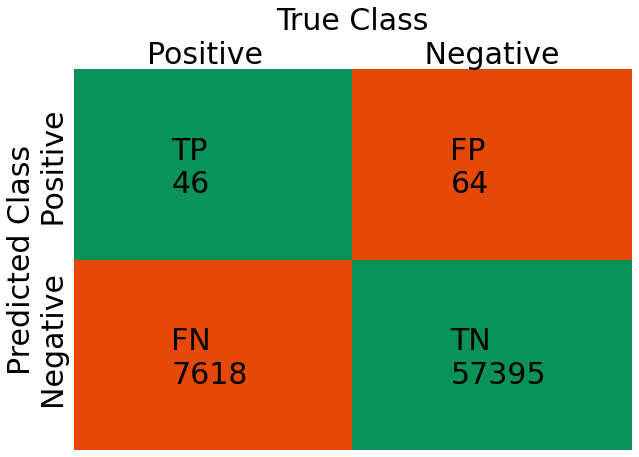

```python
ConfusionMatrix(y_test, y_pred)
```

## Area Under Curve

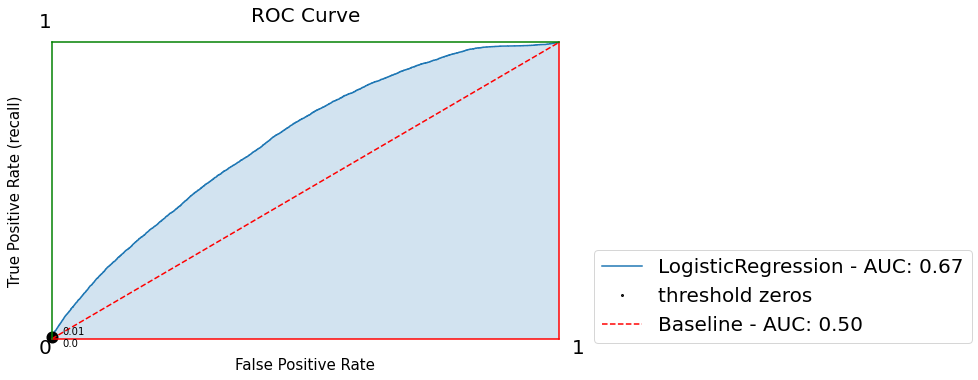

```python
models_list = [calcuate_roc_curve(LogReg,X_test)]
Graph_AUC(models_list,X_test)
```

```python
features = filtered_df[[col for col in filtered_df.columns]]
importanceDfCoef(features,LogReg).head()
```

[output not shown]

## 4. Nate's Models:

```python
df = pd.read_csv("../Project_Data/Model_Project_Data/AAA_Final_Home.csv")
df = df.drop(["Coverage_Level_Code.1"],axis=1)

y = df[['Home']]
X = df[[col for col in df.columns if col not in y.columns]]
```

### data prep

```python
from sklearn.model_selection import train_test_split

x_train,x_test,y_train,y_test=train_test_split(X,y,test_size=0.3,random_state=9) #70% training and 30% for testing
```

### model

```python
parameters = {'criterion':('gini', 'entropy'), 'max_depth':[2,4,6,8,10,12,14,16], 'min_samples_leaf':[1,2,3,4,5,6,7,8], 'max_features':("auto", "sqrt", "log2"), 'random_state': [0,1,2,3,4]}
```

#### get the model running

```python
from sklearn.tree import DecisionTreeClassifier
from sklearn.model_selection import GridSearchCV

model_home = DecisionTreeClassifier()
tuning = GridSearchCV(estimator = model_home, param_grid = parameters, scoring = 'r2')
```

### sort by the best results

```python
betterModelHome = tuning.fit(x_train, y_train)
tuning.best_params_, tuning.best_score_

model_home = DecisionTreeClassifier(criterion= 'gini', max_depth= 14, max_features = "auto", min_samples_leaf= 7, random_state= 4)
model_home.fit(x_train, y_train)
treePredHome = model_home.predict(x_test)
```

### visuals

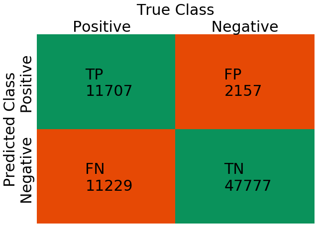

```python
classification_df(y_test, treePredHome)

importanceDf(X,model_home).head()

ConfusionMatrix(y_test,treePredHome)
```